# Business Impact Evaluation: Streaming Recommendation Engine Experiment

Hayley M

2026

## Executive Summary

This analysis evaluates whether the new recommendation engine increases average daily viewing hours compared to the existing system.

The results indicate that Group B users watched more hours on average than the control group. Statistical testing suggests this difference may be meaningful, however, analysis of group composition reveals demographic imbalance between treatment groups, particularly in gender distribution. This imbalance introduces potential bias and limits the strength of the causal conclusion.

While the findings indicate that the new engine may improve engagement, it is recommended that the company conduct a follow-up A/B test using stratified randomisation to ensure balanced demographic representation before full rollout.

## 1. Business Context

This streaming service operates in an increasingly competitive streaming market where user engagement directly influences advertising revenue and long-term customer retention.

To improve engagement, the streamer deployed a revised recommendation engine to a subset of subscribers (Group B) while maintaining the existing system for a control group (Group A). The objective of this experiment was to determine whether the new algorithm increases average daily viewing hours.

In addition to measuring engagement uplift, this analysis evaluates the integrity of the experimental design, including potential sampling bias and limitations that may affect the validity of the results.

## 2. Data Preparation

The dataset contains subscriber-level information including demographic attributes, engagement history, and daily viewing hours. The A/B test went live at 12:01am on 18 July, with Group B receiving the updated recommendation engine and Group A remaining as control.

To ensure analysis reflects post-intervention behaviour, observations prior to the intervention date were excluded.

Key variables used in the analysis include:

- **Hours_Watched_Per_Day** (primary outcome variable)
- **Group** (A = Control, B = Treatment)
- **Age**
- **Gender**
- **Social_Metric** (prior engagement indicator)
- **Demographic**
- **Months_Active**

The dataset was cleaned and renamed for clarity prior to analysis.

```r
library(dplyr)
library(ggplot2)
library(readr)
library(lubridate)
library(pwr)
```

```r
streaming_data <- read_csv("streaming_data.csv")

streaming_data$date <- lubridate::as_date(streaming_data$date, format = "%d-%b")

#filter to include only testing period
streaming <- streaming_data %>% filter(date > '2023-07-17')

streaming <- streaming %>%
  rename("Date" = "date",
         "Gender" = "gender",
         "Age" = "age",
         "Social_Metric" = "social_metric",
         "Months_Active" = "time_since_signup",
         "Demographic" = "demographic",
         "Group" = "group",
         "Hours_Watched_Per_Day" = "hours_watched"
         )
```

# Part I — Analytical Investigation

## 3. Exploratory Data Analysis

Initial exploratory analysis was conducted to understand relationships between demographic variables, engagement behaviour, and treatment allocation.

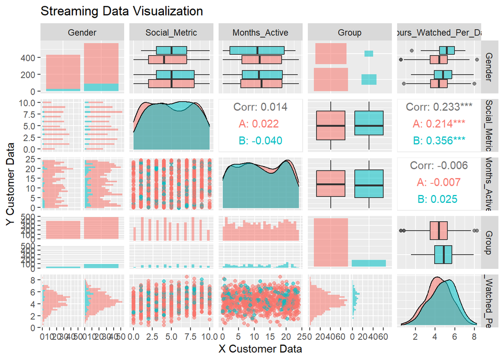

```r
#understanding relationships between variables
GGally::ggpairs(streaming, columns = c(2, 4, 5, 7, 8), aes(color = Group, alpha = 0.5),
        xlab = "X Customer Data",
        ylab = "Y Customer Data",
        title = "Streaming Data Visualization")
```

## 3. Regression Analysis: Drivers of Viewing Behaviour

Linear regression models were used to evaluate whether age, demographic grouping, and prior engagement metrics were associated with daily viewing hours.

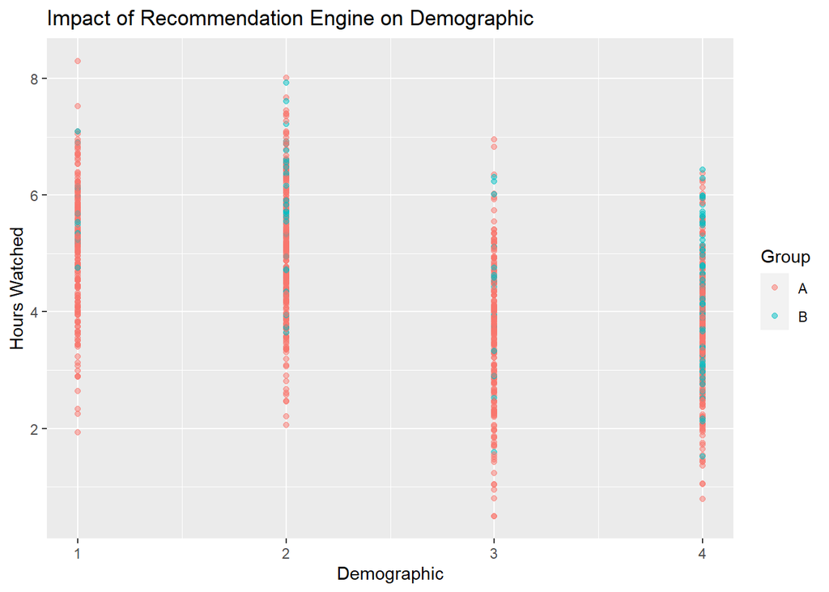

```r
#exploring linear regression
demographic_hours <- streaming %>%
  ggplot(aes(x = Demographic, y = Hours_Watched_Per_Day, color = Group)) +
  geom_point(alpha = 0.5) +
  labs(
    x = 'Demographic',
    y = 'Hours Watched',
    color = 'Group',
    title = 'Impact of Recommendation Engine on Demographic'
  )
demographic_hours
```

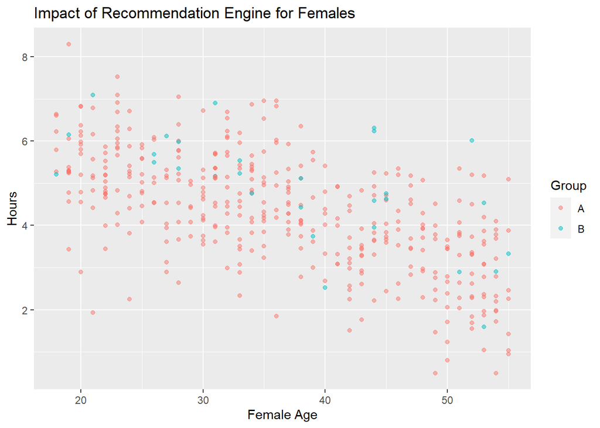

```r
#subsetting genders
Female <- streaming %>%
  filter(Demographic %in% c("1", "3"))

Male <- streaming %>%
  filter(Demographic %in% c("2", "4"))

#female, age, hours linear regression
female_age <- Female %>%
  ggplot(aes(x = Age, y = Hours_Watched_Per_Day, color = Group)) +
  geom_point(alpha = 0.5) +
  labs(
    x = 'Female Age',
    y = 'Hours',
    color = 'Group',
    title = 'Impact of Recommendation Engine for Females'
  )
female_age
```